# aer13_FinalHomeworkCode_05

Abby_Robinson

11/18/2021

#Boots for Days! ##Bootstrapping Standard Errors and CIs for Linear Models.

```r
library(curl)
```

load KamilarAndCooperData.csv dataset into R markdown file

```r
f <- curl("https://raw.githubusercontent.com/fuzzyatelin/fuzzyatelin.github.io/master/AN588_Fall21/KamilarAndCooperData.csv")
k <- read.csv(f, header = TRUE, sep = ",", stringsAsFactors = TRUE)
k
```

```
##                   Scientific_Name          Family          Genus
## 1     Allenopithecus_nigroviridis Cercopithecidae Allenopithecus
## 2             Allocebus_trichotis Cercopithecidae      Allocebus
## 3               Alouatta_belzebul        Atelidae       Alouatta
## 4                 Alouatta_caraya        Atelidae       Alouatta
## 5                Alouatta_guariba        Atelidae       Alouatta
## 6               Alouatta_palliata        Atelidae       Alouatta
## 7                  Alouatta_pigra        Atelidae       Alouatta
## 8              Alouatta_seniculus        Atelidae       Alouatta
## 9                    Aotus_azarai         Cebidae          Aotus
## 10                Aotus_brumbacki         Cebidae          Aotus
## 11                Aotus_lemurinus         Cebidae          Aotus
## 12                Aotus_nancymaae         Cebidae          Aotus
## 13                Aotus_nigriceps         Cebidae          Aotus
## 14              Aotus_trivirgatus         Cebidae          Aotus
```

[output cut: 2767 more lines]

[1] Using the “KamilarAndCooperData.csv” dataset, run a linear regression looking at log(HomeRange_km2) in relation to log(Body_mass_female_mean) and report your β coeffiecients (slope and intercept).

```r
model <- lm(log(HomeRange_km2) ~ log(Body_mass_female_mean), data = k, na.action = na.exclude) #use na.action = na.exclude here to remove NAs from the dataset

model
```

```
##
## Call:
## lm(formula = log(HomeRange_km2) ~ log(Body_mass_female_mean),
##     data = k, na.action = na.exclude)
##
## Coefficients:
##                (Intercept)  log(Body_mass_female_mean)
##                     -9.441                       1.036
```

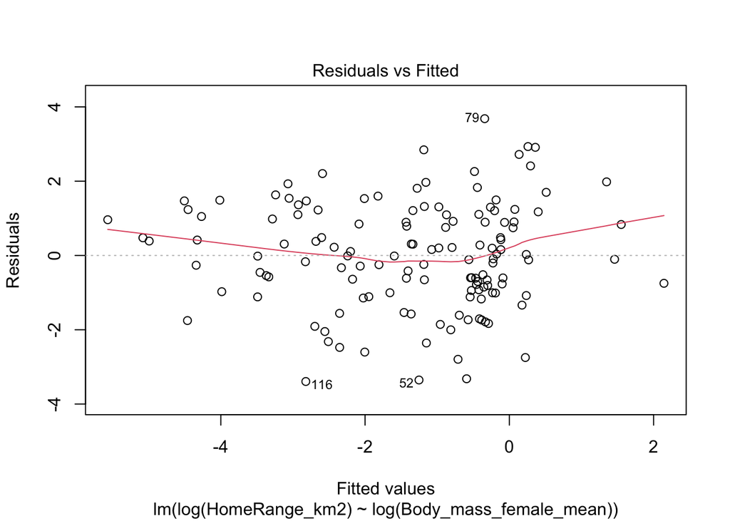

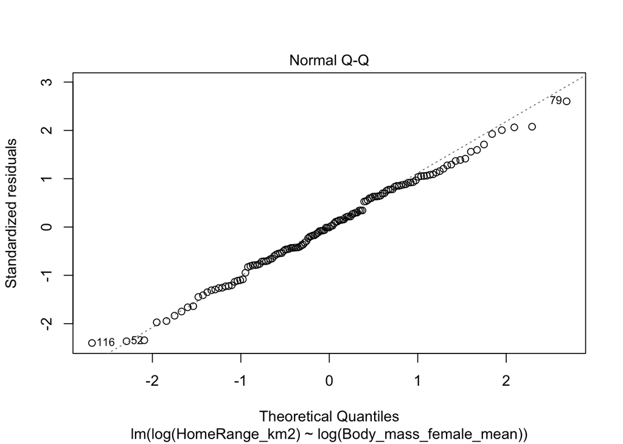

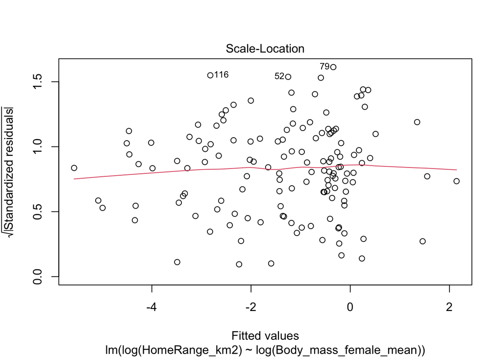

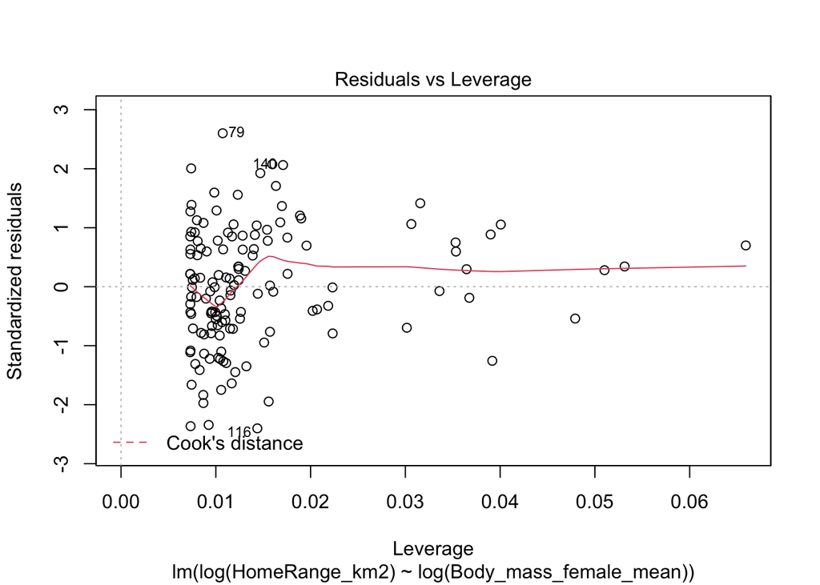

```r
##the intercept is -9.441 and the slope is 1.036

plot(model)  ##residuals look randomly distributed and the QQ plot is linear
```

[2] Then, use bootstrapping to sample from your data 1000 times with replacement, each time fitting the same model and calculating the same coefficients. This generates a sampling distribution for each β coefficient.

subset home range and body mass data to form a new dataset using as.data.frame()

```r
home <- k$HomeRange_km2

mass <- k$Body_mass_female_mean

pop.data <- as.data.frame(cbind(mass, home))

pop.data <- na.omit(pop.data)
pop.data
```

```
##        mass   home
## 5    4550.0  0.030
## 6    5350.0  0.190
## 7    6430.0  0.300
## 8    5210.0  0.100
## 9    1230.0  0.095
## 13   1040.0  0.105
## 14    933.3  0.020
## 17   8484.4  2.280
## 19   7290.0  0.730
## 20   8070.0  1.360
## 21   1307.0  0.010
## 22    766.5  0.010
## 23   8070.0  1.040
## 24   6350.0  0.413
```

[output cut: 123 more lines]

take a sample of 10 from the population

```r
sample.data <- pop.data[sample(nrow(pop.data), 10, replace = TRUE),]
sample.data
```

```
##         mass  home
## 63    2900.0 1.150
## 40     122.0 0.002
## 177   6210.0 0.210
## 60    4130.0 0.060
## 14     933.3 0.020
## 20    8070.0 1.360
## 177.1 6210.0 0.210
## 52    2700.0 0.010
## 172   6710.0 0.380
## 187    534.4 0.160
```

```r
# Containers for the coefficients
sample_coef_intercept <- NULL
sample_coef_slope <- NULL

for (i in 1:1000) {
  #Creating a resampled dataset from the sample data
  sample_d = sample.data[sample(1:nrow(sample.data), nrow(sample.data), replace = TRUE), ]

  #Running the regression on these data
  model_bootstrap <- lm(log(home) ~ log(mass), data = sample_d)

  #Saving the coefficients
  sample_coef_intercept <-
    c(sample_coef_intercept, model_bootstrap$coefficients[1])

  sample_coef_slope <-
    c(sample_coef_slope, model_bootstrap$coefficients[2])
}
```

call intercept coefficient sampling distribution

```r
sample_coef_intercept
```

[output not shown]

[output cut: 279 more lines]

[output not shown]

```r
mean(sample_coef_intercept) #mean intercept from bootstrapping
```

```
## [1] -10.80251
```

call slope coefficient sampling distribution

```r
sample_coef_slope
```

[output not shown]

[output cut: 279 more lines]

[output not shown]

```r
mean(sample_coef_slope) #mean slope from bootstrapping
```

```
## [1] 1.095372
```

Estimate the standard error for each of your β coefficients as the standard deviation of the sampling distribution from your bootstrap and determine the 95% CI for each of your β coefficients based on the appropriate quantiles from your sampling distribution.

```r
summary(model)
```

```
##
## Call:
## lm(formula = log(HomeRange_km2) ~ log(Body_mass_female_mean),
##     data = k, na.action = na.exclude)
##
## Residuals:
##     Min      1Q  Median      3Q     Max
## -3.3929 -0.9433 -0.0126  1.0944  3.6826
##
## Coefficients:
##                            Estimate Std. Error t value Pr(>|t|)
## (Intercept)                -9.44123    0.67293  -14.03   <2e-16 ***
## log(Body_mass_female_mean)  1.03643    0.08488   12.21   <2e-16 ***
## ---
## Signif. codes:  0 '***' 0.001 '**' 0.01 '*' 0.05 '.' 0.1 ' ' 1
##
## Residual standard error: 1.423 on 135 degrees of freedom
##   (76 observations deleted due to missingness)
## Multiple R-squared:  0.5248, Adjusted R-squared:  0.5213
## F-statistic: 149.1 on 1 and 135 DF,  p-value: < 2.2e-16
```

std.error() function from the plotrix package can be used to calculate standard error

```r
library(plotrix)
std.error(sample_coef_intercept)
```

```
## [1] 0.1405984
```

```r
std.error(sample_coef_slope)
```

```
## [1] 0.0164369
```

standard deviation can be calculated with the sd() function

```r
sd(sample_coef_intercept) #standard deviation for the intercept coefficient
```

```
## [1] 4.446112
```

```r
sd(sample_coef_slope) #standard deviation for the slope coefficient
```

```
## [1] 0.5197804
```

95% CI for intercept: from bootstrapping

```r
quantile(sample_coef_intercept, c(0.025, 0.975))
```

```
##       2.5%      97.5%
## -18.931610  -3.594502
```

from linear regression model

```r
quantile(model$coefficients[1])
```

```
##        0%       25%       50%       75%      100%
## -9.441231 -9.441231 -9.441231 -9.441231 -9.441231
```

95% CI for slope from bootstrapping

```r
quantile(sample_coef_slope, c(0.025, 0.975))
```

```
##      2.5%     97.5%
## 0.2304377 2.0396854
```

from linear regression model

```r
quantile(model$coefficients[2])
```

```
##       0%      25%      50%      75%     100%
## 1.036432 1.036432 1.036432 1.036432 1.036432
```

##How does the former compare to the SE estimated from your entire dataset using the formula for standard error implemented in lm()?

##How does the latter compare to the 95% CI estimated from your entire dataset?

I tried to find the confidence interval for the entire dataset using the quantile function. It seems like the 95% confidence intervals are greater in the bootstrapping analysis for both slope and intercept

##Challenges:

1. I got an error when I tried to sample from the whole population because there were too many NAs in the dataset and the sample was only pulling NAs values, but I removed the NAs and that fixed the problem
2. I originally had the “sample.data” code inside the bootstrap loop, but this was just giving the same number 1000 times when I ran the bootstrap, so I put that code outside of the actual bootstrap loop and that seemed to fix the problem!